# 4. Obesity Absolute Number with Tax

### Importing necessary libraries

```python
import pandas as pd
import numpy as np
import seaborn as sns
import matplotlib.pyplot as plt
import statsmodels.api as sm

# code to ignore warnings
import warnings
warnings.filterwarnings("ignore")

root_csv = '../csv files/'
root_pickle = '../pickle files/'
```

### Reading files

```python
df_obese_total_pivot = pd.read_pickle(root_pickle +'Obesity_Total_Pivot.pkl')
df_obese_gender_pivot = pd.read_pickle(root_pickle +'Obesity_Gender_Pivot.pkl')
df_obese_age_pivot = pd.read_pickle(root_pickle +'Obesity_Age_Pivot.pkl')
```

### Reviewing data

```python
df_obese_total_pivot.head(5)
```

|  | State | County | CountyFIPS | Year | Total Absolute | Total Percentage | Grocery Tax | Restaurant Tax | tax_delta | Population |
| --- | --- | --- | --- | --- | --- | --- | --- | --- | --- | --- |
| 0 | Alabama | Autauga County | 1001 | 2004 | 7213.0 | 21.9 | 0.04 | 0.04 | 0.0 | 32936.073633 |
| 6 | Alabama | Autauga County | 1001 | 2005 | 8093.0 | 24.0 | 0.04 | 0.04 | 0.0 | 33720.833333 |
| 12 | Alabama | Autauga County | 1001 | 2006 | 7457.0 | 21.5 | 0.04 | 0.04 | 0.0 | 34683.720930 |
| 18 | Alabama | Autauga County | 1001 | 2007 | 7467.0 | 21.1 | 0.04 | 0.04 | 0.0 | 35388.624953 |
| 24 | Alabama | Autauga County | 1001 | 2008 | 9568.0 | 26.6 | 0.04 | 0.04 | 0.0 | 35969.924296 |

```python
df_obese_gender_pivot.head(5)
```

|  | State | County | CountyFIPS | Year | Gender Absolute | Gender Percentage | Gender | Grocery Tax | Restaurant Tax | tax_delta | Population |
| --- | --- | --- | --- | --- | --- | --- | --- | --- | --- | --- | --- |
| 0 | Alabama | Autauga County | 1001 | 2004 | 3747.0 | 21.700001 | Female | 0.04 | 0.04 | 0.0 | 17267.280499 |
| 3 | Alabama | Autauga County | 1001 | 2004 | 3466.0 | 22.100000 | Male | 0.04 | 0.04 | 0.0 | 15683.257648 |
| 6 | Alabama | Autauga County | 1001 | 2005 | 4141.0 | 23.400000 | Female | 0.04 | 0.04 | 0.0 | 17696.581485 |
| 9 | Alabama | Autauga County | 1001 | 2005 | 3952.0 | 24.600000 | Male | 0.04 | 0.04 | 0.0 | 16065.040401 |
| 12 | Alabama | Autauga County | 1001 | 2006 | 3874.0 | 21.299999 | Female | 0.04 | 0.04 | 0.0 | 18187.794079 |

```python
df_obese_age_pivot.head(5)
```

|  | State | County | CountyFIPS | Year | Age Obesity Absolute | Age Obesity Percentage | Age | Grocery Tax | Restaurant Tax | tax_delta | Population |
| --- | --- | --- | --- | --- | --- | --- | --- | --- | --- | --- | --- |
| 0 | Alabama | Autauga County | 1001 | 2004 | 3411.0 | 20.700001 | 20-44 | 0.04 | 0.04 | 0.0 | 16478.260262 |
| 1 | Alabama | Autauga County | 1001 | 2004 | 2898.0 | 25.299999 | 45-64 | 0.04 | 0.04 | 0.0 | 11454.545800 |
| 2 | Alabama | Autauga County | 1001 | 2004 | 904.0 | 17.900000 | 65-beyond | 0.04 | 0.04 | 0.0 | 5050.279437 |
| 6 | Alabama | Autauga County | 1001 | 2005 | 3714.0 | 22.200001 | 20-44 | 0.04 | 0.04 | 0.0 | 16729.729155 |
| 7 | Alabama | Autauga County | 1001 | 2005 | 3379.0 | 28.500000 | 45-64 | 0.04 | 0.04 | 0.0 | 11856.140351 |

### Regression Analysis at County level data

#### 1. Baseline without controls

##### a. With Total Absolute as Response Variable:

##### Note:

Even though Total Absolute does not make sense as concluded from EDA, we are carrying regression on it.

```python
import numpy as np
import pandas as pd
import statsmodels.api as sm
from sklearn.model_selection import train_test_split
from sklearn.linear_model import LinearRegression
from sklearn.metrics import mean_squared_error, r2_score

# Assuming 'Grocery Tax' and 'Restaurant Tax' are the features
X = df_obese_total_pivot[['Grocery Tax', 'Restaurant Tax']]
y = df_obese_total_pivot['Total Absolute']

# Add a constant term to the features matrix (required for statsmodels)
X = sm.add_constant(X)

# Create and fit the linear regression model using statsmodels
stats_model = sm.OLS(y, X).fit()

# Print the summary
print(stats_model.summary())
```

```
                            OLS Regression Results
==============================================================================
Dep. Variable:         Total Absolute   R-squared:                       0.016
Model:                            OLS   Adj. R-squared:                  0.016
Method:                 Least Squares   F-statistic:                     445.5
Date:                Sun, 26 Nov 2023   Prob (F-statistic):          1.35e-192
Time:                        07:36:01   Log-Likelihood:            -6.6074e+05
No. Observations:               53352   AIC:                         1.321e+06
Df Residuals:                   53349   BIC:                         1.322e+06
Df Model:                           2
Covariance Type:            nonrobust
==================================================================================
                     coef    std err          t      P>|t|      [0.025      0.975]
----------------------------------------------------------------------------------
const           6513.9359    816.160      7.981      0.000    4914.255    8113.617
Grocery Tax    -2.918e+05    1.2e+04    -24.227      0.000   -3.15e+05   -2.68e+05
Restaurant Tax  3.095e+05    1.5e+04     20.662      0.000     2.8e+05    3.39e+05
==============================================================================
Omnibus:                    94795.033   Durbin-Watson:                   0.120
Prob(Omnibus):                  0.000   Jarque-Bera (JB):        167377694.786
Skew:                          12.727   Prob(JB):                         0.00
Kurtosis:                     276.214   Cond. No.                         60.9
==============================================================================

Notes:
[1] Standard Errors assume that the covariance matrix of the errors is correctly specified.
```

##### Conclusion:

The baseline model with response as total number of Obesity and predictor variables grocery tax and restaurant tax:

- One percent increase in grocery tax, keeping all other constant, decreases the absolute number by 2.918 x 10^5
- One percent increase in restaurant tax, keeping all other constant, increases the absolute number by 3.095 x 10^5
- p-value is close to 0 in both cases. Hence the coefficients of regression are statistically significant
- Adjusted R-square is 0.016 indicating that the model can explain only 1.6% of variation in total number of Obesity patient
- Again, this model was fitted only on absolute numbers and we will switch to a more better approach of percentages.

#### 2. With single controls

##### a. Gender Control - On Absolute Number

```python
import numpy as np
import pandas as pd
import statsmodels.api as sm
from sklearn.model_selection import train_test_split
from sklearn.linear_model import LinearRegression
from sklearn.metrics import mean_squared_error, r2_score

# One Hot Encoding Gender in predictor variable
X = pd.get_dummies(df_obese_gender_pivot[['Grocery Tax', 'Restaurant Tax', 'Gender']], columns=['Gender'], drop_first=True)
y = df_obese_gender_pivot['Gender Absolute']

# Add a constant term to the features matrix (required for statsmodels)
X = sm.add_constant(X)

# Create and fit the linear regression model using statsmodels
stats_model = sm.OLS(y, X).fit()

# Print the summary
print(stats_model.summary())
```

```
                            OLS Regression Results
==============================================================================
Dep. Variable:        Gender Absolute   R-squared:                       0.016
Model:                            OLS   Adj. R-squared:                  0.016
Method:                 Least Squares   F-statistic:                     591.0
Date:                Sun, 26 Nov 2023   Prob (F-statistic):               0.00
Time:                        07:36:01   Log-Likelihood:            -1.2479e+06
No. Observations:              106702   AIC:                         2.496e+06
Df Residuals:                  106698   BIC:                         2.496e+06
Df Model:                           3
Covariance Type:            nonrobust
==================================================================================
                     coef    std err          t      P>|t|      [0.025      0.975]
----------------------------------------------------------------------------------
const           3418.7913    303.030     11.282      0.000    2824.856    4012.727
Grocery Tax     -1.46e+05   4275.406    -34.147      0.000   -1.54e+05   -1.38e+05
Restaurant Tax  1.549e+05   5317.200     29.124      0.000    1.44e+05    1.65e+05
Gender_Male     -311.7023    177.788     -1.753      0.080    -660.164      36.759
==============================================================================
Omnibus:                   189819.245   Durbin-Watson:                   0.070
Prob(Omnibus):                  0.000   Jarque-Bera (JB):        340211416.928
Skew:                          12.767   Prob(JB):                         0.00
Kurtosis:                     278.445   Cond. No.                         69.7
==============================================================================

Notes:
[1] Standard Errors assume that the covariance matrix of the errors is correctly specified.
```

##### Conclusion:

The model with response as total number of Obesity and predictor variables grocery tax and restaurant tax and control on gender:

- One percent increase in grocery tax, keeping all other constant, decreases the absolute number by 1.46 x 10^5
- One percent increase in restaurant tax, keeping all other constant, increases the absolute number by 1.549 x 10^5
- If the gender is male, keeping all other constant, the absolute number decreases by 311.7023.
- p-value of gender male is >0.05. Hence the coefficients of regression of gender is not statistically significant
- Adjusted R-square is 0.016 indicating that the model can explain only 1.6% of variation in total number of Obesity patient
- Again, this model was fitted on absolute numbers and we will switch to a more better approach of percentages.

##### b. Age Control - On Absolute Number

```python
import numpy as np
import pandas as pd
import statsmodels.api as sm
from sklearn.model_selection import train_test_split
from sklearn.linear_model import LinearRegression
from sklearn.metrics import mean_squared_error, r2_score

# One Hot Encoding Gender in predictor variable
X = pd.get_dummies(df_obese_age_pivot[['Grocery Tax', 'Restaurant Tax', 'Age']], columns=['Age'], drop_first=True)
y = df_obese_age_pivot['Age Obesity Absolute']

# Add a constant term to the features matrix (required for statsmodels)
X = sm.add_constant(X)

# Create and fit the linear regression model using statsmodels
stats_model = sm.OLS(y, X).fit()

# Print the summary
print(stats_model.summary())
```

```
                             OLS Regression Results
================================================================================
Dep. Variable:     Age Obesity Absolute   R-squared:                       0.025
Model:                              OLS   Adj. R-squared:                  0.025
Method:                   Least Squares   F-statistic:                     1028.
Date:                  Sun, 26 Nov 2023   Prob (F-statistic):               0.00
Time:                          07:36:01   Log-Likelihood:            -1.8180e+06
No. Observations:                159995   AIC:                         3.636e+06
Df Residuals:                    159990   BIC:                         3.636e+06
Df Model:                             4
Covariance Type:              nonrobust
==================================================================================
                     coef    std err          t      P>|t|      [0.025      0.975]
----------------------------------------------------------------------------------
const           3976.2100    184.930     21.501      0.000    3613.751    4338.669
Grocery Tax    -9.729e+04   2503.233    -38.867      0.000   -1.02e+05   -9.24e+04
Restaurant Tax  1.032e+05   3113.911     33.144      0.000    9.71e+04    1.09e+05
Age_45-64       -484.1068    127.475     -3.798      0.000    -733.956    -234.258
Age_65-beyond  -4931.8196    127.506    -38.679      0.000   -5181.728   -4681.911
==============================================================================
Omnibus:                   305856.600   Durbin-Watson:                   0.453
Prob(Omnibus):                  0.000   Jarque-Bera (JB):        953182865.325
Skew:                          14.780   Prob(JB):                         0.00
Kurtosis:                     379.972   Cond. No.                         68.0
==============================================================================

Notes:
[1] Standard Errors assume that the covariance matrix of the errors is correctly specified.
```

##### Conclusion:

The model with response as total number of Obesity and predictor variables grocery tax and restaurant tax and control on age:

- One percent increase in grocery tax, keeping all other constant, decreases the absolute number by 9.729 x 10^4
- One percent increase in restaurant tax, keeping all other constant, increases the absolute number by 1.032 x 10^5
- If the age is between 45-64, keeping all other constant, the absolute number decreases by 484.1068.
- If the age is between 65-beyond, keeping all other constant, the absolute number decreases by 4931.8196.
- All p values are statistically significant
- Adjusted R-square is 0.025 indicating that the model can explain only 2.5% of variation in total number of Obesity patient
- Again, this model was fitted on absolute numbers and we will switch to a more better approach of percentages.

##### c. Total Population - On Absolute Number

```python
import numpy as np
import pandas as pd
import statsmodels.api as sm
from sklearn.model_selection import train_test_split
from sklearn.linear_model import LinearRegression
from sklearn.metrics import mean_squared_error, r2_score

# Assuming 'Grocery Tax' and 'Restaurant Tax' are the features
X = df_obese_total_pivot[['Grocery Tax', 'Restaurant Tax','Population']]
y = df_obese_total_pivot['Total Absolute']

# Add a constant term to the features matrix (required for statsmodels)
X = sm.add_constant(X)

# Create and fit the linear regression model using statsmodels
stats_model = sm.OLS(y, X).fit()

# Print the summary
print(stats_model.summary())
```

```
                            OLS Regression Results
==============================================================================
Dep. Variable:         Total Absolute   R-squared:                       0.974
Model:                            OLS   Adj. R-squared:                  0.974
Method:                 Least Squares   F-statistic:                 6.742e+05
Date:                Sun, 26 Nov 2023   Prob (F-statistic):               0.00
Time:                        07:36:01   Log-Likelihood:            -5.6351e+05
No. Observations:               53352   AIC:                         1.127e+06
Df Residuals:                   53348   BIC:                         1.127e+06
Df Model:                           3
Covariance Type:            nonrobust
==================================================================================
                     coef    std err          t      P>|t|      [0.025      0.975]
----------------------------------------------------------------------------------
const            280.8527    132.003      2.128      0.033      22.126     539.580
Grocery Tax    -4187.6355   1957.669     -2.139      0.032   -8024.683    -350.588
Restaurant Tax  1.705e+04   2430.325      7.014      0.000    1.23e+04    2.18e+04
Population         0.2451      0.000   1410.097      0.000       0.245       0.245
==============================================================================
Omnibus:                    24544.112   Durbin-Watson:                   0.370
Prob(Omnibus):                  0.000   Jarque-Bera (JB):         49772556.430
Skew:                           0.519   Prob(JB):                         0.00
Kurtosis:                     152.629   Cond. No.                     1.51e+07
==============================================================================

Notes:
[1] Standard Errors assume that the covariance matrix of the errors is correctly specified.
[2] The condition number is large, 1.51e+07. This might indicate that there are
strong multicollinearity or other numerical problems.
```

#### Conclusion:

- One percent increase in grocery tax, keeping all other constant, decreases the Obesity number by 4187.6355.
- One percent increase in restaurant tax, keeping all other constant, increases the Obesity number by 1.705 x 10^4.
- One unit increase in population, keeping all other constant, increases the Obesity number by 0.2451.
- All p-value are statistically significant
- Adjusted R-square is 0.974 indicating that the model can explain only 97.4% of variation in total number of Obesity patient
- The conditional number is large and hence we need to check for multicollinearity
- This model has good R-square value but we need to validate the linearity assumptions and if any is violated, apply necessary trasformation

```python
# Checking for multicollinearity
from statsmodels.stats.outliers_influence import variance_inflation_factor

vif_data = pd.DataFrame()
vif_data["Variable"] = X.columns
vif_data["VIF"] = [variance_inflation_factor(X.values, i) for i in range(X.shape[1])]

# Check the VIF values
print(vif_data)
```

```
         Variable        VIF
0           const  10.632575
1     Grocery Tax   1.031262
2  Restaurant Tax   1.027550
3      Population   1.016111
```

##### Inference:

The VIF for predictor variables is small and hence multicollinearity does not exist The VIF with constant variable is high. This can be fixed by scaling if needed.

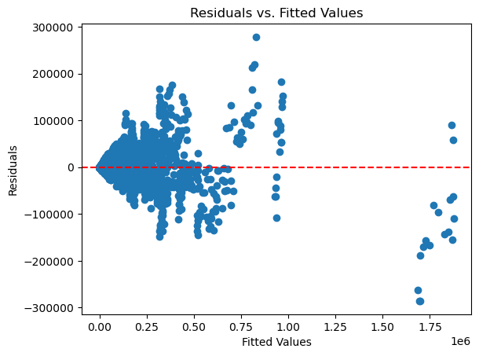

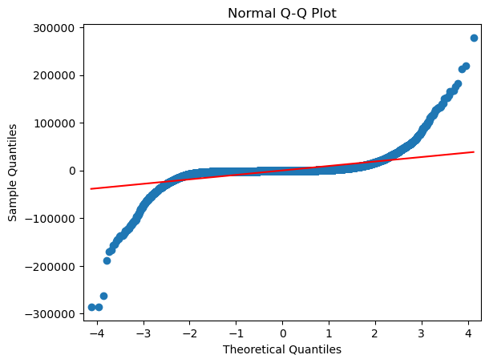

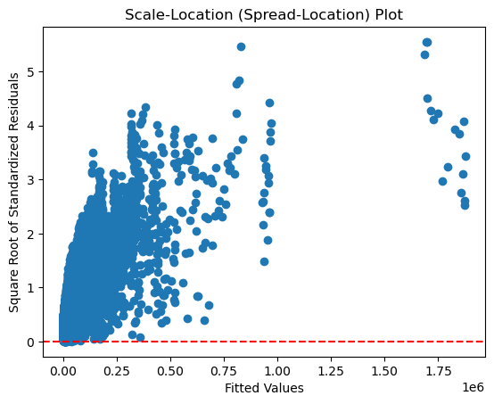

[figure not shown]

```python
# Validating for linearity assumptions

import statsmodels.api as sm
import matplotlib.pyplot as plt
import scipy.stats as stats
import numpy as np

# Assuming you have already fitted the linear regression model named 'model'

# Get fitted values and residuals
fitted_values = stats_model.fittedvalues
residuals = stats_model.resid

# 1. Residuals vs. Fitted Values Plot
plt.scatter(fitted_values, residuals)
plt.xlabel('Fitted Values')
plt.ylabel('Residuals')
plt.title('Residuals vs. Fitted Values')
plt.axhline(y=0, color='r', linestyle='--')  # Add a horizontal line at y=0
plt.show()

# 2. Normal Q-Q Plot
sm.qqplot(residuals, line='s')
plt.title('Normal Q-Q Plot')
plt.show()

# 3. Scale-Location (Spread-Location) Plot
sqrt_standardized_residuals = np.sqrt(np.abs(stats_model.get_influence().resid_studentized_internal))
plt.scatter(fitted_values, sqrt_standardized_residuals)
plt.xlabel('Fitted Values')
plt.ylabel('Square Root of Standardized Residuals')
plt.title('Scale-Location (Spread-Location) Plot')
plt.axhline(y=0, color='r', linestyle='--')  # Add a horizontal line at y=0
plt.show()

# 4. Residuals vs. Predictor Plot for ''
plt.scatter(df_obese_total_pivot['Population'], residuals)
plt.xlabel('Population')
plt.ylabel('Residuals')
plt.title('Residuals vs. Tax Delta')
plt.axhline(y=0, color='r', linestyle='--')  # Add a horizontal line at y=0
plt.show()
```

##### Inference:

Linearity assumptions are being violated. Lets apply Box-Cox transformations to fix that.

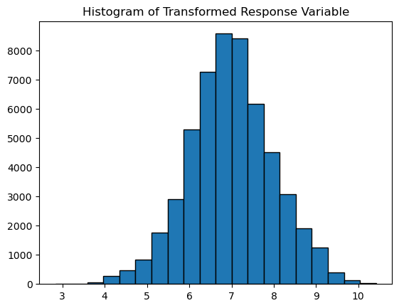

```
Lambda Value: -0.04831233596949974
                            OLS Regression Results
==============================================================================
Dep. Variable:                      y   R-squared:                       0.267
Model:                            OLS   Adj. R-squared:                  0.267
Method:                 Least Squares   F-statistic:                     6490.
Date:                Sun, 26 Nov 2023   Prob (F-statistic):               0.00
Time:                        07:36:04   Log-Likelihood:                -67449.
No. Observations:               53352   AIC:                         1.349e+05
Df Residuals:                   53348   BIC:                         1.349e+05
Df Model:                           3
Covariance Type:            nonrobust
==================================================================================
                     coef    std err          t      P>|t|      [0.025      0.975]
----------------------------------------------------------------------------------
const              6.5878      0.012    544.713      0.000       6.564       6.611
Grocery Tax       -4.3422      0.179    -24.209      0.000      -4.694      -3.991
Restaurant Tax     5.7694      0.223     25.911      0.000       5.333       6.206
Population      2.076e-06   1.59e-08    130.355      0.000    2.04e-06    2.11e-06
==============================================================================
Omnibus:                    20947.156   Durbin-Watson:                   0.110
Prob(Omnibus):                  0.000   Jarque-Bera (JB):           337350.640
Skew:                          -1.461   Prob(JB):                         0.00
Kurtosis:                      14.967   Cond. No.                     1.51e+07
==============================================================================

Notes:
[1] Standard Errors assume that the covariance matrix of the errors is correctly specified.
[2] The condition number is large, 1.51e+07. This might indicate that there are
strong multicollinearity or other numerical problems.
```

```python
# Applying the Box-Cox transformation

# Apply Box-Cox Transformation to Response Variable
y_transformed, lambda_value = stats.boxcox(y + 1)  # Adding 1 to handle zero values

# Visualize the Transformed Response Variable
plt.hist(y_transformed, bins=20, edgecolor='black')
plt.title('Histogram of Transformed Response Variable')
plt.show()

# Check Lambda Value
print(f'Lambda Value: {lambda_value}')

# Fit a new model using the transformed response variable
stats_model_transformed = sm.OLS(y_transformed, X).fit()

# Print the summary of the transformed model
print(stats_model_transformed.summary())
```

##### Conclusion:

```python
import statsmodels.api as sm
from sklearn.preprocessing import StandardScaler
import pandas as pd

df_obese_scaled = df_obese_total_pivot.reset_index(drop=True)
df_obese_scaled

# Extract the independent variables (features) from your DataFrame
X = df_obese_scaled[['Grocery Tax', 'Restaurant Tax', 'Population']]

# Extract the dependent variable from your DataFrame
y = df_obese_scaled['Total Absolute']

# Initialize the StandardScaler
scaler = StandardScaler()

# Fit and transform the independent variables
X_scaled = scaler.fit_transform(X)

# Create a new DataFrame with the scaled features
X_scaled_df = pd.DataFrame(X_scaled, columns=X.columns)

# Add a constant term to the independent variables
X_scaled_df = sm.add_constant(X_scaled_df)

# Fit the linear regression model
model = sm.OLS(y, X_scaled_df).fit()

# Display the summary
print(model.summary())
```

```
                            OLS Regression Results
==============================================================================
Dep. Variable:         Total Absolute   R-squared:                       0.974
Model:                            OLS   Adj. R-squared:                  0.974
Method:                 Least Squares   F-statistic:                 6.742e+05
Date:                Sun, 26 Nov 2023   Prob (F-statistic):               0.00
Time:                        07:36:04   Log-Likelihood:            -5.6351e+05
No. Observations:               53352   AIC:                         1.127e+06
Df Residuals:                   53348   BIC:                         1.127e+06
Df Model:                           3
Covariance Type:            nonrobust
==================================================================================
                     coef    std err          t      P>|t|      [0.025      0.975]
----------------------------------------------------------------------------------
const           1.908e+04     40.482    471.206      0.000     1.9e+04    1.92e+04
Grocery Tax      -87.9385     41.110     -2.139      0.032    -168.515      -7.362
Restaurant Tax   287.8448     41.036      7.014      0.000     207.414     368.276
Population      5.754e+04     40.807   1410.097      0.000    5.75e+04    5.76e+04
==============================================================================
Omnibus:                    24544.112   Durbin-Watson:                   0.370
Prob(Omnibus):                  0.000   Jarque-Bera (JB):         49772556.429
Skew:                           0.519   Prob(JB):                         0.00
Kurtosis:                     152.629   Cond. No.                         1.20
==============================================================================

Notes:
[1] Standard Errors assume that the covariance matrix of the errors is correctly specified.
```

##### Since the above model violates linearity assumptions, applying Box-Cox transformation to scaled parameters

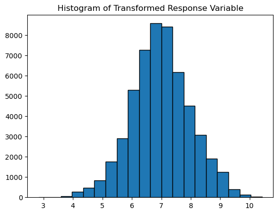

```
Lambda Value: -0.04831233596949974
                            OLS Regression Results
==============================================================================
Dep. Variable:                      y   R-squared:                       0.267
Model:                            OLS   Adj. R-squared:                  0.267
Method:                 Least Squares   F-statistic:                     6490.
Date:                Sun, 26 Nov 2023   Prob (F-statistic):               0.00
Time:                        07:36:04   Log-Likelihood:                -67449.
No. Observations:               53352   AIC:                         1.349e+05
Df Residuals:                   53348   BIC:                         1.349e+05
Df Model:                           3
Covariance Type:            nonrobust
==================================================================================
                     coef    std err          t      P>|t|      [0.025      0.975]
----------------------------------------------------------------------------------
const              6.9876      0.004   1883.990      0.000       6.980       6.995
Grocery Tax       -0.0912      0.004    -24.209      0.000      -0.099      -0.084
Restaurant Tax     0.0974      0.004     25.911      0.000       0.090       0.105
Population         0.4874      0.004    130.355      0.000       0.480       0.495
==============================================================================
Omnibus:                    20947.156   Durbin-Watson:                   0.110
Prob(Omnibus):                  0.000   Jarque-Bera (JB):           337350.642
Skew:                          -1.461   Prob(JB):                         0.00
Kurtosis:                      14.967   Cond. No.                         1.20
==============================================================================

Notes:
[1] Standard Errors assume that the covariance matrix of the errors is correctly specified.
```

```python
# Applying the Box-Cox transformation

# Apply Box-Cox Transformation to Response Variable
y_transformed, lambda_value = stats.boxcox(y + 1)  # Adding 1 to handle zero values

# Visualize the Transformed Response Variable
plt.hist(y_transformed, bins=20, edgecolor='black')
plt.title('Histogram of Transformed Response Variable')
plt.show()

# Check Lambda Value
print(f'Lambda Value: {lambda_value}')

# Fit a new model using the transformed response variable
stats_model_transformed = sm.OLS(y_transformed, X_scaled_df).fit()

# Print the summary of the transformed model
print(stats_model_transformed.summary())
```

##### Conclusion:

The model with response as number of Obesity and predictor variable tax and control on population:

- The lambda value is -0.048. Indicating the new model fit is on (((Obesity number^-0.048)-1)/-0.048). We will call this response as transformed y.
- One percent increase in scaled grocery tax, keeping all other constant, decreases the transformed y by 0.0912.
- One percent increase in scaled restaurant tax, keeping all other constant, increases the transformed by 0.0974.
- One unit increase in scaled population, keeping all other constant, increases the transformed y by 0.4874.
- All p-value are statistically significant
- Adjusted R-square is 0.267 indicating that the model can explain only 26.7% of variation in total number of Obesity patient
- Conditonal large number error has been fixed

#### 3. With multiple controls

##### a. Total Population and Gender - On Absolute Number

```python
import numpy as np
import pandas as pd
import statsmodels.api as sm
from sklearn.model_selection import train_test_split
from sklearn.linear_model import LinearRegression
from sklearn.metrics import mean_squared_error, r2_score

# Assuming 'Grocery Tax' and 'Restaurant Tax' are the features
X = pd.get_dummies(df_obese_gender_pivot[['Grocery Tax', 'Restaurant Tax','Population', 'Gender']], columns=['Gender'], drop_first=True)
y = df_obese_gender_pivot['Gender Absolute']

# Add a constant term to the features matrix (required for statsmodels)
X = sm.add_constant(X)

# Create and fit the linear regression model using statsmodels
stats_model = sm.OLS(y, X).fit()

# Print the summary
print(stats_model.summary())
```

```
                            OLS Regression Results
==============================================================================
Dep. Variable:        Gender Absolute   R-squared:                       0.973
Model:                            OLS   Adj. R-squared:                  0.973
Method:                 Least Squares   F-statistic:                 9.568e+05
Date:                Sun, 26 Nov 2023   Prob (F-statistic):               0.00
Time:                        07:36:05   Log-Likelihood:            -1.0563e+06
No. Observations:              106702   AIC:                         2.113e+06
Df Residuals:                  106697   BIC:                         2.113e+06
Df Model:                           4
Covariance Type:            nonrobust
==================================================================================
                     coef    std err          t      P>|t|      [0.025      0.975]
----------------------------------------------------------------------------------
const             55.8246     50.348      1.109      0.268     -42.858     154.507
Grocery Tax    -1899.0245    713.812     -2.660      0.008   -3298.086    -499.963
Restaurant Tax  8292.9912    886.155      9.358      0.000    6556.140       1e+04
Population         0.2451      0.000   1939.833      0.000       0.245       0.245
Gender_Male      172.3155     29.523      5.837      0.000     114.451     230.180
==============================================================================
Omnibus:                    54130.179   Durbin-Watson:                   0.368
Prob(Omnibus):                  0.000   Jarque-Bera (JB):        110102290.420
Skew:                           0.802   Prob(JB):                         0.00
Kurtosis:                     160.360   Cond. No.                     7.55e+06
==============================================================================

Notes:
[1] Standard Errors assume that the covariance matrix of the errors is correctly specified.
[2] The condition number is large, 7.55e+06. This might indicate that there are
strong multicollinearity or other numerical problems.
```

##### Conclusion:

- One percent increase in grocery tax, keeping all other constant, decreases the Obesity number by 1899.0249.
- One percent increase in restaurant tax, keeping all other constant, increases the Obesity number by 8292.9912.
- One unit increase in population, keeping all other constant, increases the Obesity number by 0.2451
- If the gender is male, keeping all other constant, increases the Obesity number by 172.3155.
- All p-value are statistically significant
- Adjusted R-square is 0.973 indicating that the model can explain only 97.3% of variation in total number of Obesity patient
- The conditional number is large and hence we need to check for multicollinearity
- This model has good R-square value but we need to validate the linearity assumptions and if any is violated, apply necessary trasformation

```python
# Checking for multicollinearity
from statsmodels.stats.outliers_influence import variance_inflation_factor

vif_data = pd.DataFrame()
vif_data["Variable"] = X.columns
vif_data["VIF"] = [variance_inflation_factor(X.values, i) for i in range(X.shape[1])]

# Check the VIF values
print(vif_data)
```

```
         Variable        VIF
0           const  11.634381
1     Grocery Tax   1.031238
2  Restaurant Tax   1.027541
3      Population   1.016146
4     Gender_Male   1.000071
```

##### Inference:

The VIF for predictor variables is small and hence multicollinearity does not exist The VIF with constant variable is high. This can be fixed by scaling if needed.

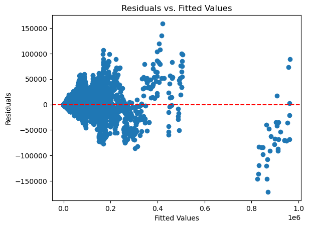

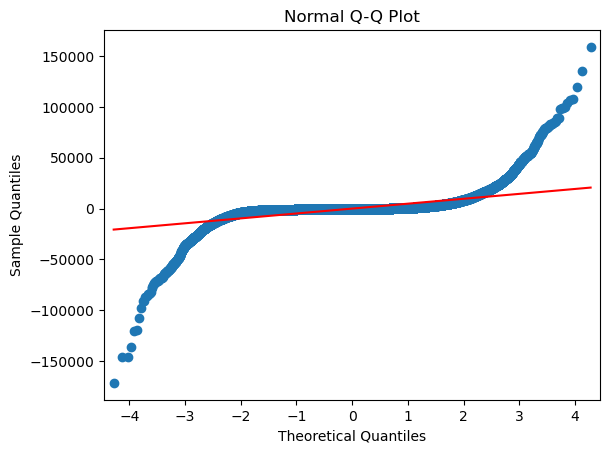

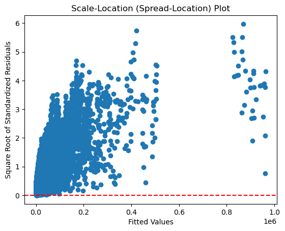

[figure not shown]

```python
# Validating for linearity assumptions

import statsmodels.api as sm
import matplotlib.pyplot as plt
import scipy.stats as stats
import numpy as np

# Assuming you have already fitted the linear regression model named 'model'

# Get fitted values and residuals
fitted_values = stats_model.fittedvalues
residuals = stats_model.resid

# 1. Residuals vs. Fitted Values Plot
plt.scatter(fitted_values, residuals)
plt.xlabel('Fitted Values')
plt.ylabel('Residuals')
plt.title('Residuals vs. Fitted Values')
plt.axhline(y=0, color='r', linestyle='--')  # Add a horizontal line at y=0
plt.show()

# 2. Normal Q-Q Plot
sm.qqplot(residuals, line='s')
plt.title('Normal Q-Q Plot')
plt.show()

# 3. Scale-Location (Spread-Location) Plot
sqrt_standardized_residuals = np.sqrt(np.abs(stats_model.get_influence().resid_studentized_internal))
plt.scatter(fitted_values, sqrt_standardized_residuals)
plt.xlabel('Fitted Values')
plt.ylabel('Square Root of Standardized Residuals')
plt.title('Scale-Location (Spread-Location) Plot')
plt.axhline(y=0, color='r', linestyle='--')  # Add a horizontal line at y=0
plt.show()

# 4. Residuals vs. Predictor Plot for ''
plt.scatter(df_obese_gender_pivot['Population'], residuals)
plt.xlabel('Population')
plt.ylabel('Residuals')
plt.title('Residuals vs. Tax Delta')
plt.axhline(y=0, color='r', linestyle='--')  # Add a horizontal line at y=0
plt.show()
```

##### Since the above model violates linearity assumptions, applying Box-Cox transoformation

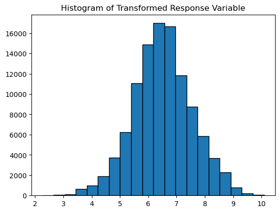

```
Lambda Value: -0.0484987596575893
                            OLS Regression Results
==============================================================================
Dep. Variable:                      y   R-squared:                       0.267
Model:                            OLS   Adj. R-squared:                  0.267
Method:                 Least Squares   F-statistic:                     9708.
Date:                Sun, 26 Nov 2023   Prob (F-statistic):               0.00
Time:                        07:36:09   Log-Likelihood:            -1.3853e+05
No. Observations:              106702   AIC:                         2.771e+05
Df Residuals:                  106697   BIC:                         2.771e+05
Df Model:                           4
Covariance Type:            nonrobust
==================================================================================
                     coef    std err          t      P>|t|      [0.025      0.975]
----------------------------------------------------------------------------------
const              6.0892      0.009    657.892      0.000       6.071       6.107
Grocery Tax       -4.4651      0.131    -34.027      0.000      -4.722      -4.208
Restaurant Tax     5.9640      0.163     36.611      0.000       5.645       6.283
Population      4.277e-06   2.32e-08    184.121      0.000    4.23e-06    4.32e-06
Gender_Male        0.0233      0.005      4.289      0.000       0.013       0.034
==============================================================================
Omnibus:                    41736.548   Durbin-Watson:                   0.064
Prob(Omnibus):                  0.000   Jarque-Bera (JB):           670711.285
Skew:                          -1.456   Prob(JB):                         0.00
Kurtosis:                      14.933   Cond. No.                     7.55e+06
==============================================================================

Notes:
[1] Standard Errors assume that the covariance matrix of the errors is correctly specified.
[2] The condition number is large, 7.55e+06. This might indicate that there are
strong multicollinearity or other numerical problems.
```

```python
# Applying the Box-Cox transformation

# Apply Box-Cox Transformation to Response Variable
y_transformed, lambda_value = stats.boxcox(y + 1)  # Adding 1 to handle zero values

# Visualize the Transformed Response Variable
plt.hist(y_transformed, bins=20, edgecolor='black')
plt.title('Histogram of Transformed Response Variable')
plt.show()

# Check Lambda Value
print(f'Lambda Value: {lambda_value}')

# Fit a new model using the transformed response variable
stats_model_transformed = sm.OLS(y_transformed, X).fit()

# Print the summary of the transformed model
print(stats_model_transformed.summary())
```

##### Conclusion:

```python
import statsmodels.api as sm
from sklearn.preprocessing import StandardScaler
import pandas as pd

df_obese_scaled = df_obese_gender_pivot.reset_index(drop=True)
df_obese_scaled

# Extract the independent variables (features) from your DataFrame
X = pd.get_dummies(df_obese_gender_pivot[['Grocery Tax', 'Restaurant Tax','Population', 'Gender']], columns=['Gender'], drop_first=True)

# Extract the dependent variable from your DataFrame
y = df_obese_scaled['Gender Absolute']

# Initialize the StandardScaler
scaler = StandardScaler()

# Fit and transform the independent variables
X_scaled = scaler.fit_transform(X)

# Create a new DataFrame with the scaled features
X_scaled_df = pd.DataFrame(X_scaled, columns=X.columns)

# Add a constant term to the independent variables
X_scaled_df = sm.add_constant(X_scaled_df)

# Fit the linear regression model
model = sm.OLS(y, X_scaled_df).fit()

# Display the summary
print(model.summary())
```

```
                            OLS Regression Results
==============================================================================
Dep. Variable:        Gender Absolute   R-squared:                       0.973
Model:                            OLS   Adj. R-squared:                  0.973
Method:                 Least Squares   F-statistic:                 9.568e+05
Date:                Sun, 26 Nov 2023   Prob (F-statistic):               0.00
Time:                        07:36:09   Log-Likelihood:            -1.0563e+06
No. Observations:              106702   AIC:                         2.113e+06
Df Residuals:                  106697   BIC:                         2.113e+06
Df Model:                           4
Covariance Type:            nonrobust
==================================================================================
                     coef    std err          t      P>|t|      [0.025      0.975]
----------------------------------------------------------------------------------
const           9548.0467     14.761    646.845      0.000    9519.115    9576.978
Grocery Tax      -39.8787     14.990     -2.660      0.008     -69.258     -10.499
Restaurant Tax   140.0282     14.963      9.358      0.000     110.701     169.355
Population      2.886e+04     14.880   1939.833      0.000    2.88e+04    2.89e+04
Gender_Male       86.1577     14.761      5.837      0.000      57.225     115.090
==============================================================================
Omnibus:                    54130.179   Durbin-Watson:                   0.368
Prob(Omnibus):                  0.000   Jarque-Bera (JB):        110102290.422
Skew:                           0.802   Prob(JB):                         0.00
Kurtosis:                     160.360   Cond. No.                         1.20
==============================================================================

Notes:
[1] Standard Errors assume that the covariance matrix of the errors is correctly specified.
```

##### Since the above model violates linearity assumptions, applying Box-Cox transformation to scaled parameters

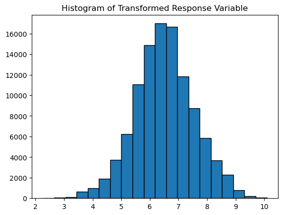

```
Lambda Value: -0.0484987596575893
                            OLS Regression Results
==============================================================================
Dep. Variable:                      y   R-squared:                       0.267
Model:                            OLS   Adj. R-squared:                  0.267
Method:                 Least Squares   F-statistic:                     9708.
Date:                Sun, 26 Nov 2023   Prob (F-statistic):               0.00
Time:                        07:36:10   Log-Likelihood:            -1.3853e+05
No. Observations:              106702   AIC:                         2.771e+05
Df Residuals:                  106697   BIC:                         2.771e+05
Df Model:                           4
Covariance Type:            nonrobust
==================================================================================
                     coef    std err          t      P>|t|      [0.025      0.975]
----------------------------------------------------------------------------------
const              6.5142      0.003   2400.659      0.000       6.509       6.520
Grocery Tax       -0.0938      0.003    -34.027      0.000      -0.099      -0.088
Restaurant Tax     0.1007      0.003     36.611      0.000       0.095       0.106
Population         0.5036      0.003    184.121      0.000       0.498       0.509
Gender_Male        0.0116      0.003      4.289      0.000       0.006       0.017
==============================================================================
Omnibus:                    41736.549   Durbin-Watson:                   0.064
Prob(Omnibus):                  0.000   Jarque-Bera (JB):           670711.302
Skew:                          -1.456   Prob(JB):                         0.00
Kurtosis:                      14.933   Cond. No.                         1.20
==============================================================================

Notes:
[1] Standard Errors assume that the covariance matrix of the errors is correctly specified.
```

```python
# Applying the Box-Cox transformation

# Apply Box-Cox Transformation to Response Variable
y_transformed, lambda_value = stats.boxcox(y + 1)  # Adding 1 to handle zero values

# Visualize the Transformed Response Variable
plt.hist(y_transformed, bins=20, edgecolor='black')
plt.title('Histogram of Transformed Response Variable')
plt.show()

# Check Lambda Value
print(f'Lambda Value: {lambda_value}')

# Fit a new model using the transformed response variable
stats_model_transformed = sm.OLS(y_transformed, X_scaled_df).fit()

# Print the summary of the transformed model
print(stats_model_transformed.summary())
```

##### Conclusion:

The model with response as number of Obesity and predictor variable tax and population:

- The lambda value is -0.048. Indicating the new model fit is on (((Obesity number^-0.048)-1)/-0.048). We will call this response as transformed y.
- One percent increase in scaled grocery tax, keeping all other constant, decreases the transformed y by 0.09
- One percent increase in scaled restaurant tax, keeping all other constant, increases the transformed by 0.1007.
- One percent increase in scaled gender, keeping all other constant, increases the transformed by 0.0116.
- One unit increase in scaled population, keeping all other constant, increases the transformed y by 0.5036.
- All p-value are statistically significant
- Adjusted R-square is 0.267 indicating that the model can explain only 26.7% of variation in total number of Obesity patient
- Conditonal large number error has been fixed

##### b. Total Population and Age - On Absolute Number

```python
import numpy as np
import pandas as pd
import statsmodels.api as sm
from sklearn.model_selection import train_test_split
from sklearn.linear_model import LinearRegression
from sklearn.metrics import mean_squared_error, r2_score

# Assuming 'Grocery Tax' and 'Restaurant Tax' are the features
X = pd.get_dummies(df_obese_age_pivot[['Grocery Tax', 'Restaurant Tax', 'Population','Age']], columns=['Age'], drop_first=True)
y = df_obese_age_pivot['Age Obesity Absolute']

# Add a constant term to the features matrix (required for statsmodels)
X = sm.add_constant(X)

# Create and fit the linear regression model using statsmodels
stats_model = sm.OLS(y, X).fit()

# Print the summary
print(stats_model.summary())
```

```
                             OLS Regression Results
================================================================================
Dep. Variable:     Age Obesity Absolute   R-squared:                       0.960
Model:                              OLS   Adj. R-squared:                  0.960
Method:                   Least Squares   F-statistic:                 7.769e+05
Date:                  Sun, 26 Nov 2023   Prob (F-statistic):               0.00
Time:                          07:36:10   Log-Likelihood:            -1.5616e+06
No. Observations:                159995   AIC:                         3.123e+06
Df Residuals:                    159989   BIC:                         3.123e+06
Df Model:                             5
Covariance Type:              nonrobust
==================================================================================
                     coef    std err          t      P>|t|      [0.025      0.975]
----------------------------------------------------------------------------------
const           -329.0171     37.315     -8.817      0.000    -402.154    -255.880
Grocery Tax    -2269.5558    506.573     -4.480      0.000   -3262.428   -1276.684
Restaurant Tax  6578.1358    629.181     10.455      0.000    5344.954    7811.318
Population         0.2428      0.000   1945.096      0.000       0.243       0.243
Age_45-64       1485.0315     25.697     57.791      0.000    1434.667    1535.396
Age_65-beyond   -162.1627     25.800     -6.285      0.000    -212.729    -111.596
==============================================================================
Omnibus:                    80051.178   Durbin-Watson:                   1.385
Prob(Omnibus):                  0.000   Jarque-Bera (JB):        911526615.670
Skew:                           0.375   Prob(JB):                         0.00
Kurtosis:                     372.774   Cond. No.                     5.40e+06
==============================================================================

Notes:
[1] Standard Errors assume that the covariance matrix of the errors is correctly specified.
[2] The condition number is large, 5.4e+06. This might indicate that there are
strong multicollinearity or other numerical problems.
```

##### Conclusion:

- One percent increase in grocery tax, keeping all other constant, decreases the Obesity number by 2269.5558.
- One percent increase in restaurant tax, keeping all other constant, increases the Obesity number by 6578.
- One unit increase in population, keeping all other constant, increases the Obesity number by 0.2428
- Adjusted R-square is 0.96 indicating that the model can explain only 96% of variation in total number of Obesity patient
- The conditional number is large and hence we need to check for multicollinearity
- This model has good R-square value but we need to validate the linearity assumptions and if any is violated, apply necessary trasformation

```python
# Checking for multicollinearity
from statsmodels.stats.outliers_influence import variance_inflation_factor

vif_data = pd.DataFrame()
vif_data["Variable"] = X.columns
vif_data["VIF"] = [variance_inflation_factor(X.values, i) for i in range(X.shape[1])]

# Check the VIF values
print(vif_data)
```

```
         Variable        VIF
0           const  12.668226
1     Grocery Tax   1.029672
2  Restaurant Tax   1.026495
3      Population   1.022988
4       Age_45-64   1.335252
5   Age_65-beyond   1.345333
```

##### Inference:

The VIF for predictor variables is small and hence multicollinearity does not exist The VIF with constant variable is high. This can be fixed by scaling if needed.

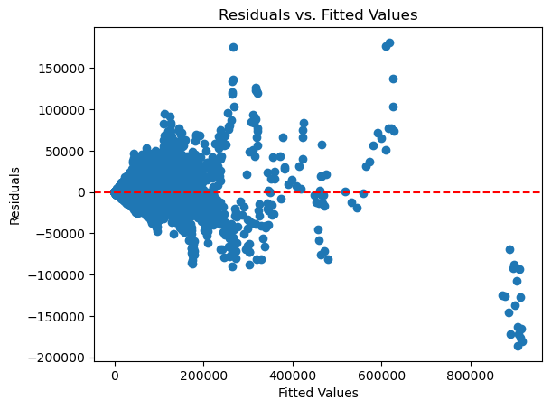

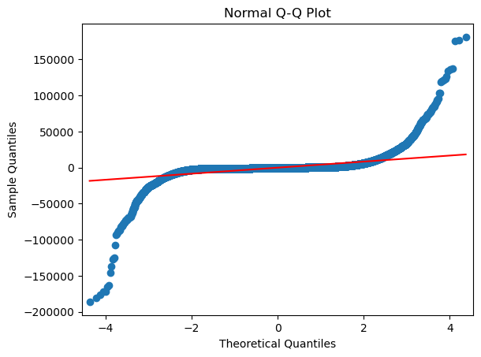

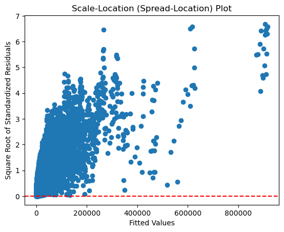

[figure not shown]

```python
# Validating for linearity assumptions

import statsmodels.api as sm
import matplotlib.pyplot as plt
import scipy.stats as stats
import numpy as np

# Assuming you have already fitted the linear regression model named 'model'

# Get fitted values and residuals
fitted_values = stats_model.fittedvalues
residuals = stats_model.resid

# 1. Residuals vs. Fitted Values Plot
plt.scatter(fitted_values, residuals)
plt.xlabel('Fitted Values')
plt.ylabel('Residuals')
plt.title('Residuals vs. Fitted Values')
plt.axhline(y=0, color='r', linestyle='--')  # Add a horizontal line at y=0
plt.show()

# 2. Normal Q-Q Plot
sm.qqplot(residuals, line='s')
plt.title('Normal Q-Q Plot')
plt.show()

# 3. Scale-Location (Spread-Location) Plot
sqrt_standardized_residuals = np.sqrt(np.abs(stats_model.get_influence().resid_studentized_internal))
plt.scatter(fitted_values, sqrt_standardized_residuals)
plt.xlabel('Fitted Values')
plt.ylabel('Square Root of Standardized Residuals')
plt.title('Scale-Location (Spread-Location) Plot')
plt.axhline(y=0, color='r', linestyle='--')  # Add a horizontal line at y=0
plt.show()

# 4. Residuals vs. Predictor Plot for ''
plt.scatter(df_obese_age_pivot['Population'], residuals)
plt.xlabel('Population')
plt.ylabel('Residuals')
plt.title('Residuals vs. Tax Delta')
plt.axhline(y=0, color='r', linestyle='--')  # Add a horizontal line at y=0
plt.show()
```

##### Since the above model violates linearity assumptions, applying Box-Cox transoformation

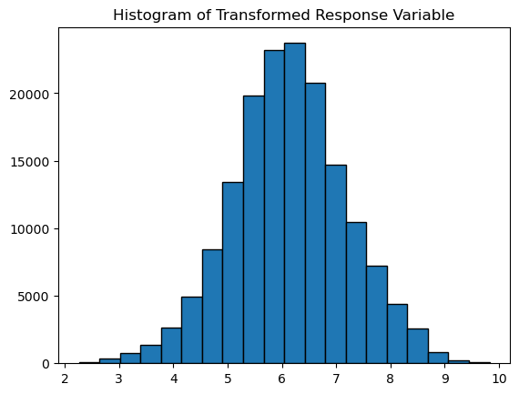

```
Lambda Value: -0.05081197153056619
                            OLS Regression Results
==============================================================================
Dep. Variable:                      y   R-squared:                       0.275
Model:                            OLS   Adj. R-squared:                  0.275
Method:                 Least Squares   F-statistic:                 1.214e+04
Date:                Sun, 26 Nov 2023   Prob (F-statistic):               0.00
Time:                        07:36:16   Log-Likelihood:            -2.1082e+05
No. Observations:              159995   AIC:                         4.216e+05
Df Residuals:                  159989   BIC:                         4.217e+05
Df Model:                           5
Covariance Type:            nonrobust
==================================================================================
                     coef    std err          t      P>|t|      [0.025      0.975]
----------------------------------------------------------------------------------
const              5.7937      0.008    720.499      0.000       5.778       5.809
Grocery Tax       -4.8597      0.109    -44.517      0.000      -5.074      -4.646
Restaurant Tax     6.6326      0.136     48.918      0.000       6.367       6.898
Population      5.543e-06   2.69e-08    206.017      0.000    5.49e-06     5.6e-06
Age_45-64          0.1147      0.006     20.704      0.000       0.104       0.126
Age_65-beyond     -0.3518      0.006    -63.275      0.000      -0.363      -0.341
==============================================================================
Omnibus:                    67049.929   Durbin-Watson:                   0.183
Prob(Omnibus):                  0.000   Jarque-Bera (JB):          1690486.487
Skew:                          -1.460   Prob(JB):                         0.00
Kurtosis:                      18.654   Cond. No.                     5.40e+06
==============================================================================

Notes:
[1] Standard Errors assume that the covariance matrix of the errors is correctly specified.
[2] The condition number is large, 5.4e+06. This might indicate that there are
strong multicollinearity or other numerical problems.
```

```python
# Applying the Box-Cox transformation

# Apply Box-Cox Transformation to Response Variable
y_transformed, lambda_value = stats.boxcox(y + 1)  # Adding 1 to handle zero values

# Visualize the Transformed Response Variable
plt.hist(y_transformed, bins=20, edgecolor='black')
plt.title('Histogram of Transformed Response Variable')
plt.show()

# Check Lambda Value
print(f'Lambda Value: {lambda_value}')

# Fit a new model using the transformed response variable
stats_model_transformed = sm.OLS(y_transformed, X).fit()

# Print the summary of the transformed model
print(stats_model_transformed.summary())
```

##### Conclusion:

```python
import statsmodels.api as sm
from sklearn.preprocessing import StandardScaler
import pandas as pd

df_obese_scaled = df_obese_age_pivot.reset_index(drop=True)
df_obese_scaled

# Extract the independent variables (features) from your DataFrame
X = pd.get_dummies(df_obese_scaled[['Grocery Tax', 'Restaurant Tax','Population', 'Age']], columns=['Age'], drop_first=True)
# Extract the dependent variable from your DataFrame
y = df_obese_scaled['Age Obesity Absolute']

# Initialize the StandardScaler
scaler = StandardScaler()

# Fit and transform the independent variables
X_scaled = scaler.fit_transform(X)

# Create a new DataFrame with the scaled features
X_scaled_df = pd.DataFrame(X_scaled, columns=X.columns)

# Add a constant term to the independent variables
X_scaled_df = sm.add_constant(X_scaled_df)

# Fit the linear regression model
model = sm.OLS(y, X_scaled_df).fit()

# Display the summary
print(model.summary())
```

```
                             OLS Regression Results
================================================================================
Dep. Variable:     Age Obesity Absolute   R-squared:                       0.960
Model:                              OLS   Adj. R-squared:                  0.960
Method:                   Least Squares   F-statistic:                 7.769e+05
Date:                  Sun, 26 Nov 2023   Prob (F-statistic):               0.00
Time:                          07:36:16   Log-Likelihood:            -1.5616e+06
No. Observations:                159995   AIC:                         3.123e+06
Df Residuals:                    159989   BIC:                         3.123e+06
Df Model:                             5
Covariance Type:              nonrobust
==================================================================================
                     coef    std err          t      P>|t|      [0.025      0.975]
----------------------------------------------------------------------------------
const           6360.9100     10.484    606.726      0.000    6340.362    6381.458
Grocery Tax      -47.6623     10.638     -4.480      0.000     -68.513     -26.811
Restaurant Tax   111.0534     10.622     10.455      0.000      90.235     131.872
Population      2.063e+04     10.604   1945.096      0.000    2.06e+04    2.06e+04
Age_45-64        700.1140     12.115     57.791      0.000     676.370     723.858
Age_65-beyond    -76.4329     12.160     -6.285      0.000    -100.267     -52.599
==============================================================================
Omnibus:                    80051.178   Durbin-Watson:                   1.385
Prob(Omnibus):                  0.000   Jarque-Bera (JB):        911526615.789
Skew:                           0.375   Prob(JB):                         0.00
Kurtosis:                     372.774   Cond. No.                         1.75
==============================================================================

Notes:
[1] Standard Errors assume that the covariance matrix of the errors is correctly specified.
```

##### Since the above model violates linearity assumptions, applying Box-Cox transformation to scaled parameters

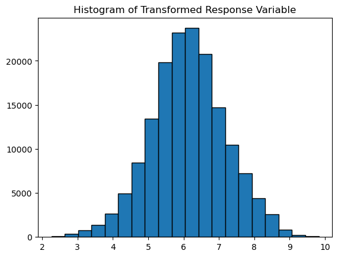

```
Lambda Value: -0.05081197153056619
                            OLS Regression Results
==============================================================================
Dep. Variable:                      y   R-squared:                       0.275
Model:                            OLS   Adj. R-squared:                  0.275
Method:                 Least Squares   F-statistic:                 1.214e+04
Date:                Sun, 26 Nov 2023   Prob (F-statistic):               0.00
Time:                        07:36:17   Log-Likelihood:            -2.1082e+05
No. Observations:              159995   AIC:                         4.216e+05
Df Residuals:                  159989   BIC:                         4.217e+05
Df Model:                           5
Covariance Type:            nonrobust
==================================================================================
                     coef    std err          t      P>|t|      [0.025      0.975]
----------------------------------------------------------------------------------
const              6.1367      0.002   2716.242      0.000       6.132       6.141
Grocery Tax       -0.1021      0.002    -44.517      0.000      -0.107      -0.098
Restaurant Tax     0.1120      0.002     48.918      0.000       0.107       0.116
Population         0.4708      0.002    206.017      0.000       0.466       0.475
Age_45-64          0.0541      0.003     20.704      0.000       0.049       0.059
Age_65-beyond     -0.1658      0.003    -63.275      0.000      -0.171      -0.161
==============================================================================
Omnibus:                    67049.930   Durbin-Watson:                   0.183
Prob(Omnibus):                  0.000   Jarque-Bera (JB):          1690486.585
Skew:                          -1.460   Prob(JB):                         0.00
Kurtosis:                      18.654   Cond. No.                         1.75
==============================================================================

Notes:
[1] Standard Errors assume that the covariance matrix of the errors is correctly specified.
```

```python
# Applying the Box-Cox transformation

# Apply Box-Cox Transformation to Response Variable
y_transformed, lambda_value = stats.boxcox(y + 1)  # Adding 1 to handle zero values

# Visualize the Transformed Response Variable
plt.hist(y_transformed, bins=20, edgecolor='black')
plt.title('Histogram of Transformed Response Variable')
plt.show()

# Check Lambda Value
print(f'Lambda Value: {lambda_value}')

# Fit a new model using the transformed response variable
stats_model_transformed = sm.OLS(y_transformed, X_scaled_df).fit()

# Print the summary of the transformed model
print(stats_model_transformed.summary())
```

##### Conclusion:

The model with response as number of Obesity and predictor variable tax and control on age and population:

- The lambda value is -0.05. Indicating the new model fit is on (((Obesity number^-0.05)-1)/-0.05). We will call this response as transformed y.
- One percent increase in scaled grocery tax, keeping all other constant, decreases the transformed y by 0.1021
- One percent increase in scaled restaurant tax, keeping all other constant, increases the transformed by 0.1120.
- One unit increase in scaled population, keeping all other constant, increases the transformed y by 0.4708.
- All p-value are statistically significant
- Adjusted R-square is 0.275 indicating that the model can explain only 27.5% of variation in total number of Obesity patient
- Conditonal large number error has been fixed

### Final Conclusion:

- The best model for explaining Obesity Number variation with Tax, after accounting for necessary controls and corrections of assumptions, is the model with response,(((Obesity number^-0.05)-1)/-0.05); and scaled predictor grocery tax, restaurant tax and control on population and age
- This model explains for 27.5% variability in Obesity number
- We shall continue to research the impact on Obesity percentage and also a study on tax delta.